# Analysis of GPU Malware Evidence in Cloud Computing.

Thomas Williamson

College of Charleston

Thursday, December 5, 2024

# Background & Problem Statement

- Importance
- Problem Statement
- Research Goal

## Importance of the Research

GPU based cloud computing is critical due to its ability to efficiently handle computationally intensive tasks & has become indispensable across various fields.

### AI & ML

- Deep Learning
- Training Large Models

### Scientific Research

- Computational Biology
- Climate Modeling
- High-Performance Computing

## Background

### Cloud GPU Service Industry

- Current market value ~3 **Billion**
- Projected to grow to ~50 **Billion** by 2032
- This **does not** account for the value of what the service is producing for the market’s clients!

## Background

### Security issues have been prevalent.

1. {CUDA} Leaks: Information Leakage in {GPU} Architectures (Pietro, Lombardi, and Villani 2013)
2. The Process of Reverse Engineering GPU Malware and Provide Protection to GPUS (Albabtain and Yang 2018)
3. Cybercriminal sells tool to hide malware in AMD, NVIDIA GPUs (Ilascu 2021)
4. Listening to LLM Responses Through Leaked GPU Local Memory (Sorensen and Khlaaf 2024)
5. (“CVE-2024-0071” 2024) “… vulnerability may lead to code execution, denial of service, **escalation of privileges**, information disclosure, and data tampering.”
6. (“CVE-2024-0073” 2024) “… A successful exploit of this vulnerability may lead to code execution, denial of service, **escalation of privileges**, …”
7. (“CVE-2024-0074” 2024) “… a vulnerability where an attacker may access a memory location after the end of the buffer.”
8. (“CVE-2024-0077” 2024) “…allows a guest OS to allocate resources for which the guest OS **is not authorized**.”

Those CVEs are just the **High** severity entries for **one** patch this year.

[The patch had several more medium severity CVEs]

Most of these were from reviewing cited papers from one section out of **ten** from (Huq et al. 2024)!

## The Problem

Security Issues

**+**

Valuable assets & content.

That makes the assets and

content a likely target.

## The Research Goal

Investigate the cloud based

GPU computing environment

for signs of GPU based

malware.

## The Research Goal - Concerns

To be clear, by investigating the GPU computing environment for signs of malware what the research is attempting to study would be considered an

**information leak**.

## The Research Goal - Concerns

### The data we want to study is:

Data from prior service users or co-users.

- GPU ‘kernel’ code.
- GPU kernel state.
  - Registers
  - Stack memory.
  - Statics memory region.
- GPU memory contents.

# Methodology

- Data Gathering Approach
- Overview of the technology.
- Data Gathering Implementation
- Results

## Methodology - Approach

Gather as Much Information As Possible

- Host Information - cpu, memory size, temperature, computer name, kernel version …
- GPU Information - Driver Version, Tools Version, GPU type, GPU Memory …
- Compiled GPU Kernel Code for data gathering apparatus.
- Get the raw data from the GPU to exfiltrate.
- Generate validation data.
- Capture validation data for verification later.

Zip it all up.

Hash the zip file.

Send the data to the central repository.

## Overview - System

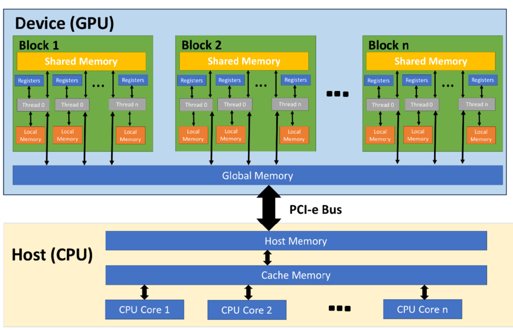

A block diagram of a CPU-GPU computing model.

## Overview - Memory

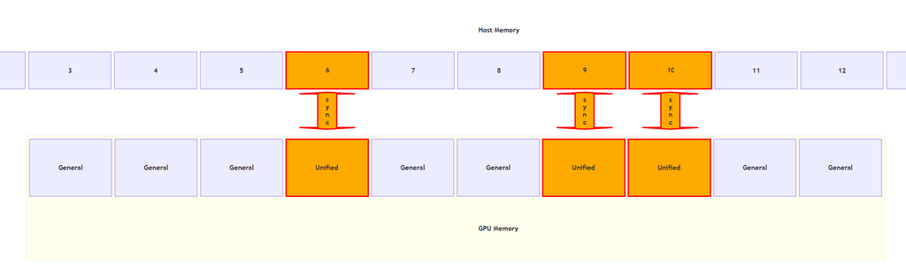

A Diagram of GPU ‘Unified’ Memory

## Methodology - Implementation

Host vector:

## Methodology - Implementation

Host vector:

Allocate unified memory and read that.

## Methodology - Implementation

Host vector:

Allocate unified memory and read that.

## Methodology - Implementation

Host vector:

Allocate unified memory and read that.

Use debugging tool `cuda-gdb`:

- Create a core-dump file of GPU.

## Methodology - Implementation

Host vector:

Allocate unified memory and read that.

Use debugging tool `cuda-gdb`:

- Create a core-dump file of GPU. Works, but will only dump allocated memory.

## Methodology - Implementation

Host vector:

Allocate unified memory and read that.

Use debugging tool `cuda-gdb`:

- Create a core-dump file of GPU. Works, but will only dump allocated memory.
- Manually inspect the data using cuda-gdb commands.

## Methodology - Implementation

Host vector:

Allocate unified memory and read that.

Use debugging tool `cuda-gdb`:

- Create a core-dump file of GPU. Works, but will only dump allocated memory.
- Manually inspect the data using cuda-gdb commands. Again only gives access to what I have mapped.

## Methodology - Implementation

Host vector:

Use debugging tool `cuda-gdb`:

GPU Kernel vector:

- Try to get raw code.

## Methodology - Implementation

Host vector:

Use debugging tool `cuda-gdb`:

GPU Kernel vector:

- Try to get raw code via pointer addressing. Code is unified mapped.

## Methodology - Implementation

Host vector:

Use debugging tool `cuda-gdb`:

GPU Kernel vector:

- Try to get raw code via pointer addressing. Code is unified mapped.
- Try to get kernel state via stack space.

## Methodology - Implementation

Host vector:

Use debugging tool `cuda-gdb`:

GPU Kernel vector:

- Try to get raw code via pointer addressing. Code is unified mapped.
- Try to get kernel state via stack space. Stack is unified mapped.

## Methodology - Implementation

Host vector:

Use debugging tool `cuda-gdb`:

GPU Kernel vector:

- Try to get raw code via pointer addressing. Code is unified mapped.
- Try to get kernel state via stack space. Stack is unified mapped.
- Try to get kernel state via static space.

## Methodology - Implementation

Host vector:

Use debugging tool `cuda-gdb`:

GPU Kernel vector:

- Try to get raw code via pointer addressing. Code is unified mapped.
- Try to get kernel state via stack space. Stack is unified mapped.
- Try to get kernel state via static space. Statics area is unified mapped.

## Methodology - Implementation

Host vector:

Use debugging tool `cuda-gdb`:

GPU Kernel vector:

- Try to get kernel state via stack space. Stack is unified mapped.
- Try to get kernel state via static space. Statics area is unified mapped.
- Try to get heap data using out of bounds access.

## Methodology - Implementation

Host vector:

Use debugging tool `cuda-gdb`:

GPU Kernel vector:

- Try to get kernel state via stack space. Stack is unified mapped.
- Try to get kernel state via static space. Statics area is unified mapped.
- Try to get heap data using out of bounds access. Nope.

## Methodology - Implementation

Host vector:

Use debugging tool `cuda-gdb`:

GPU Kernel vector:

- Try to get kernel state via static space. Statics area is unified mapped.
- Try to get heap data using out of bounds access. Nope.
- Try to get heap data using on GPU malloc.

## Methodology - Implementation

Host vector:

Use debugging tool `cuda-gdb`:

GPU Kernel vector:

- Try to get kernel state via static space. Statics area is unified mapped.
- Try to get heap data using out of bounds access. Nope.
- Try to get heap data using on GPU malloc. Nope.

## Methodology - Implementation

Host vector:

Allocate unified memory and read that.

Use debugging tool `cuda-gdb`:

- Create a core-dump file of GPU. Works, but will only dump allocated memory.
- Manually inspect the data using cuda-gdb commands. Again only gives access to what I have mapped.

GPU Kernel vector:

- Try to get raw code via pointer addressing. Code is unified mapped.
- Try to get kernel state via stack space. Stack is unified mapped.
- Try to get kernel state via static space. Statics area is unified mapped.
- Try to get heap data using out of bounds access. Nope.
- Try to get heap data using on GPU malloc. Nope.

## Methodology - Implementation

Host vector:

Allocate unified memory and read that.

Use debugging tool `cuda-gdb`:

- Create a core-dump file of GPU. Works, but will only dump allocated memory.
- Manually inspect the data using cuda-gdb commands. Again only gives access to what I have mapped.

GPU Kernel vector:

- Try to get raw code via pointer addressing. Code is unified mapped.
- Try to get kernel state via stack space. Stack is unified mapped.
- Try to get kernel state via static space. Statics area is unified mapped.
- Try to get heap data using out of bounds access. Nope.
- Try to get heap data using on GPU malloc. Nope.

## Methodology - Implementation

Host vector:

GPU Kernel vector:

## Methodology - Implementation

Host vector:

GPU Kernel vector:

?

## Next Step

### None

### Takeaway

Security has improved rapidly.

The information leak I was targeting was generally patched a little over a year ago.

LeftoverLocals: Listening to LLM Responses Through Leaked GPU Local Memory (Sorensen and Khlaaf 2024)

# The Pivot

- New Research Direction
- Proposed Methodology

## Pivot Options

Investigate Firmware for Signs of Tampering.

Power Consumption Analysis.

Timing Attacks.

Direct Code Analysis.

## Pivot Options

Direct Code Analysis.

## Direct Code Analysis

A recent research paper was published regarding malware code out in the open on the **Hugging Face** service (Casey, Santos, and Mirakhorli 2024).

Additionally, there is more research on **Hugging Face** vulnerabilities (Kathikar et al. 2023).

## Direct Code Analysis

A recent research paper was published regarding malware code out in the open on the **Hugging Face** service (Casey, Santos, and Mirakhorli 2024).

This paper analyzes projects hosted on Hugging Face that both use vulnerable serialization techniques, and looked for projects that used those vulnerabilities to inject **malware**!

Additionally, there is more research on **Hugging Face** vulnerabilities (Kathikar et al. 2023).

## Direct Code Analysis

A recent research paper was published regarding malware code out in the open on the **Hugging Face** service (Casey, Santos, and Mirakhorli 2024).

This paper analyzes projects hosted on Hugging Face that both use vulnerable serialization techniques, and looked for projects that used those vulnerabilities to inject **malware**!

I plan to use some of its methodology to perform a similar analysis; however, focusing instead on GPU kernel code to try and identify malicious code.

Additionally, there is more research on **Hugging Face** vulnerabilities (Kathikar et al. 2023).

## Direct Code Analysis

A recent research paper was published regarding malware code out in the open on the **Hugging Face** service (Casey, Santos, and Mirakhorli 2024).

Additionally, there is more research on **Hugging Face** vulnerabilities (Kathikar et al. 2023).

This paper analyzes projects on **Hugging Face** to link them to **GitHub** repos and perform software supply-chain analysis on the projects to assess vulnerabilities.

## Direct Code Analysis

A recent research paper was published regarding malware code out in the open on the **Hugging Face** service (Casey, Santos, and Mirakhorli 2024).

Additionally, there is more research on **Hugging Face** vulnerabilities (Kathikar et al. 2023).

This paper analyzes projects on **Hugging Face** to link them to **GitHub** repos and perform software supply-chain analysis on the projects to assess vulnerabilities.

For my research pivot it highlights a method of analysis for projects on **Hugging Face** to identify links to their **GitHub** code repos.

## Research Questions

1. Can we identify malicious kernel code?
2. Can we find malicious kernel code in **Hugging Face** projects?
3. If we find malicious kernel code can we link it to repos?

   If yes can we analyze:
   1. History for attack vector development insight?
   2. Forks for other usages?
   3. Software supply-chain links if the repo is used in other projects?
   4. Exposure based on popularity of the given **Hugging Face** project, **GitHub** repo, and linked projects/repos?

## Challenges

1. Analysis Methodology

   How do we approach code analysis to identify malicious kernel code?

   As far as my current literature reviews the available sample source will be miniscule.
2. Statistical Concerns

   Will there be anything to find? (Casey, Santos, and Mirakhorli 2024, sec. IV) studied 4,023 projects and identified ~13k files in those projects that were vulnerable.

   **Fourteen** files out of the ~13k were malicious. If exploiting GPUs for malware is not highly prevalent we may have to drastically increase the sample size for the projects.

   Additionally, the number of code files that contain kernel code we would anticipate to be **significantly** fewer.
3. Linking Probability

   For such a potentially small sample size how likely is it the developer(s) of the malware would have a **GitHub** repo?

   On the other hand with a small sample set it may be easy to directly search **GitHub** for anything found.

# References

Albabtain, Yazeed, and Baijian Yang. 2018. “The Process of Reverse Engineering GPU Malware and Provide Protection to GPUS.” In *2018 17th IEEE International Conference on Trust, Security and Privacy in Computing and Communications/ 12th IEEE International Conference on Big Data Science and Engineering (TrustCom/BigDataSE)*, 1669–73. https://doi.org/10.1109/TrustCom/BigDataSE.2018.00248.

Casey, Beatrice, Joanna C. S. Santos, and Mehdi Mirakhorli. 2024. “A Large-Scale Exploit Instrumentation Study of AI/ML Supply Chain Attacks in Hugging Face Models.” https://arxiv.org/abs/2410.04490.

“CVE-2024-0071.” 2024. https://cve.mitre.org/cgi-bin/cvename.cgi?name=CVE-2024-0071.

“CVE-2024-0073.” 2024. https://cve.mitre.org/cgi-bin/cvename.cgi?name=CVE-2024-0073.

“CVE-2024-0074.” 2024. https://cve.mitre.org/cgi-bin/cvename.cgi?name=CVE-2024-0074.

“CVE-2024-0077.” 2024. https://cve.mitre.org/cgi-bin/cvename.cgi?name=CVE-2024-0077.

Huq, Numaan, Philippe Lin, Roel Reyes, and Charles Perine. 2024. “A Survey of Cloud-Based GPU Threats and Their Impact on AI, HPC, and Cloud Computing.” Trend Research, Tech. Rep.

Ilascu, Ionut. 2021. “Cybercriminal Sells Tool to Hide Malware in AMD, NVIDIA GPUs.” https://www.bleepingcomputer.com/news/security/cybercriminal-sells-tool-to-hide-malware-in-amd-nvidia-gpus/#comments.

Kathikar, Adhishree, Aishwarya Nair, Ben Lazarine, Agrim Sachdeva, and Sagar Samtani. 2023. “Assessing the Vulnerabilities of the Open-Source Artificial Intelligence (AI) Landscape: A Large-Scale Analysis of the Hugging Face Platform.” In *2023 IEEE International Conference on Intelligence and Security Informatics (ISI)*, 1–6. https://doi.org/10.1109/ISI58743.2023.10297271.

Pietro, Roberto Di, Flavio Lombardi, and Antonio Villani. 2013. “CUDA Leaks: Information Leakage in GPU Architectures.” *CoRR* abs/1305.7383. http://arxiv.org/abs/1305.7383.

Sorensen, Tyler, and Heidy Khlaaf. 2024. “LeftoverLocals: Listening to LLM Responses Through Leaked GPU Local Memory.” *arXiv Preprint arXiv:2401.16603*.